# Scitsitats Code File

- children against sex

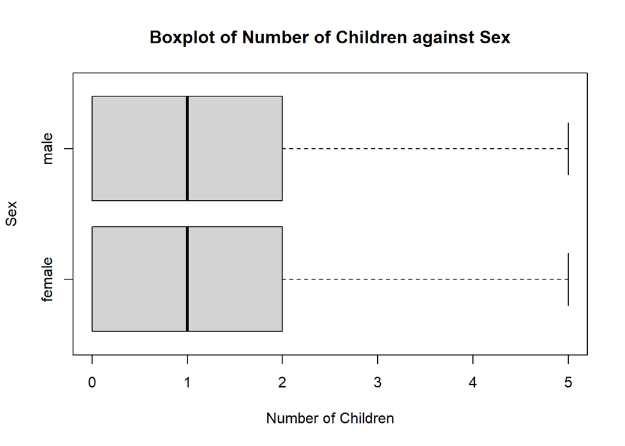

```r
bchildren.sex <- boxplot(df$children~df$sex,
               horizontal = TRUE,
               xlab = "Number of Children",
               ylab = "Sex",
               main = "Boxplot of Number of Children against Sex")
```

no association

- sex against smoker

```r
sex_smoker <- df %>%
  count(sex, smoker)

sex_smoker.spread <- sex_smoker %>%
  spread(key = smoker, value = n, fill = 0)

sex_smoker.spread[is.na(sex_smoker.spread)] <- 0

kable(sex_smoker.spread, caption = "Contingency table for Sex and Smoking Status")
```

Contingency table for Sex and Smoking Status

| sex | no | yes |
| --- | --- | --- |
| female | 547 | 115 |
| male | 517 | 159 |

[figure not shown]

```r
sex_smoker.barmatrix <- as.matrix(sex_smoker.spread[,c(2, 3)])

bar_Col <- c("pink","brown")

barplot(sex_smoker.barmatrix,
        names.arg = c("yes", "no"),
        col = bar_Col,
        beside = TRUE,
        ylim = c(0,700),
        ylab = "Number of Beneficiaries",
        main = "Frequency of Females / Males by Smoking Status")

legend("topright",
       fill = bar_Col,
       legend = sex_smoker.spread$sex,
       title = "Sex")
```

no association

- region against sex

```r
region_sex <- df %>%
  count(sex, region)

region_sex.spread <- region_sex %>%
  spread(key = region, value = n, fill = 0)

region_sex.spread[is.na(region_sex.spread)] <- 0

kable(region_sex.spread, caption = "Contingency table for Sex and Region")
```

Contingency table for Sex and Region

| sex | northeast | northwest | southeast | southwest |
| --- | --- | --- | --- | --- |
| female | 161 | 164 | 175 | 162 |
| male | 163 | 161 | 189 | 163 |

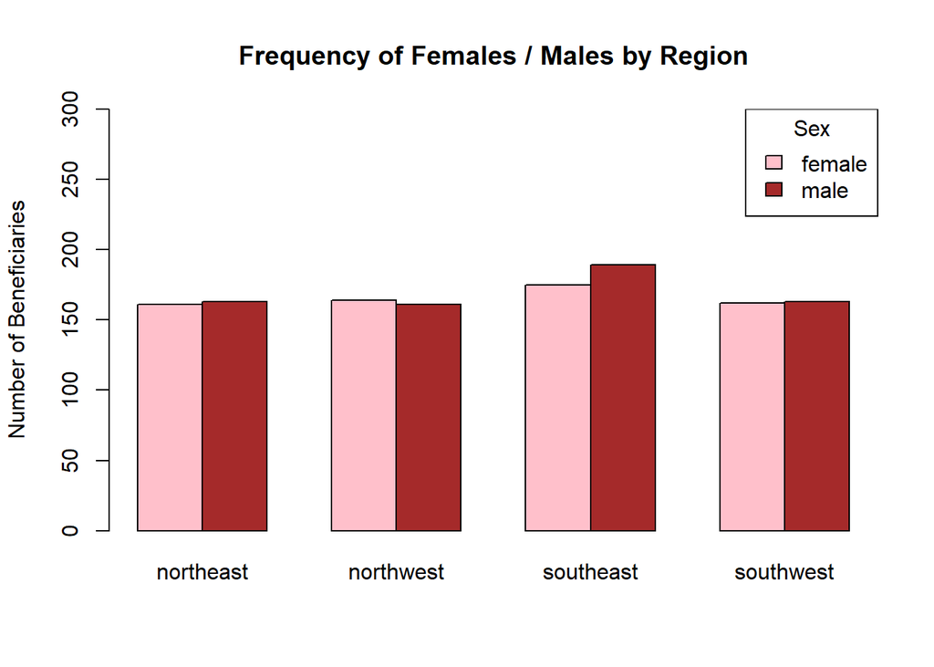

```r
region_sex.barmatrix2 <- as.matrix(region_sex.spread[,c(2:5)])

bar_Col2 <- c("pink","brown")

barplot(region_sex.barmatrix2,
        names.arg = c("northeast", "northwest", "southeast", "southwest"),
        col = bar_Col2,
        beside = TRUE,
        ylim = c(0,300),
        ylab = "Number of Beneficiaries",
        main = "Frequency of Females / Males by Region")

legend("topright",
       fill = bar_Col2,
       legend = region_sex.spread$sex,
       title = "Sex")
```

no association

- bmi against children

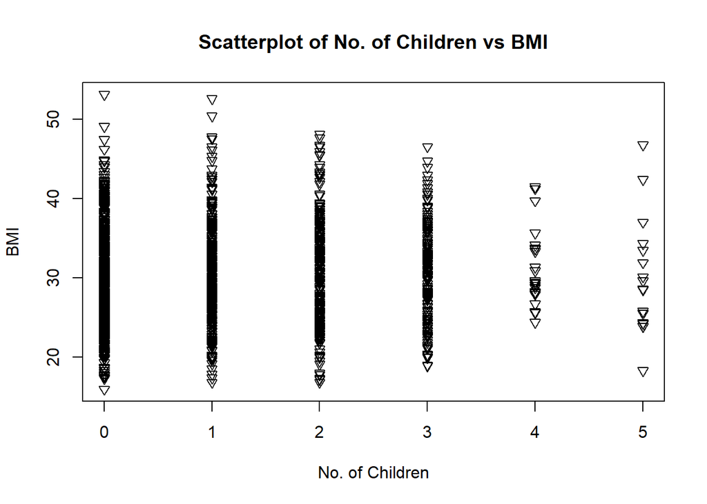

```r
plot(df$children,
     df$bmi,
     main = "Scatterplot of No. of Children vs BMI",
     xlab = "No. of Children",
     ylab = "BMI",
     pch = 6)
```

no association

- bmi against smoker

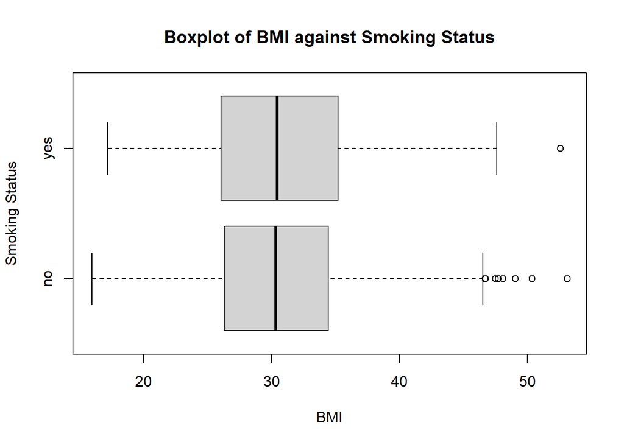

```r
bbmi.smoke <- boxplot(df$bmi~df$smoke,
               horizontal = TRUE,
               xlab = "BMI",
               ylab = "Smoking Status",
               main = "Boxplot of BMI against Smoking Status")
```

no association

- bmi against region

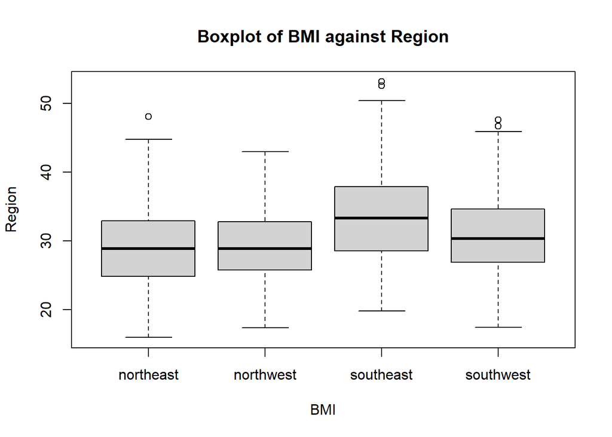

```r
bbmi.region <- boxplot(df$bmi~df$region,
               xlab = "BMI",
               ylab = "Region",
               main = "Boxplot of BMI against Region")
```

some association for southeast (?)

- children against smoker

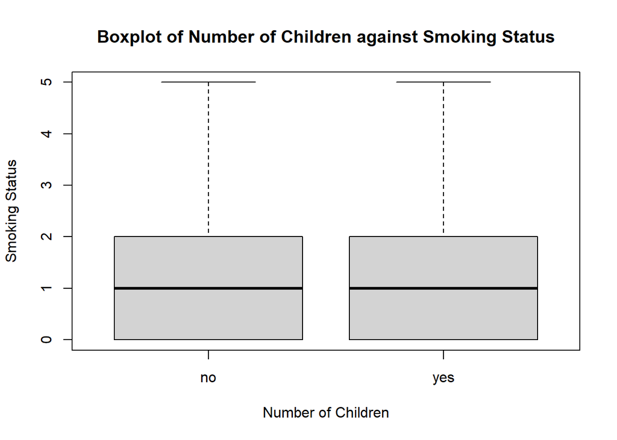

```r
bchild.smoker <- boxplot(df$children~df$smoker,
               xlab = "Number of Children",
               ylab = "Smoking Status",
               main = "Boxplot of Number of Children against Smoking Status")
```

no association

- children against region

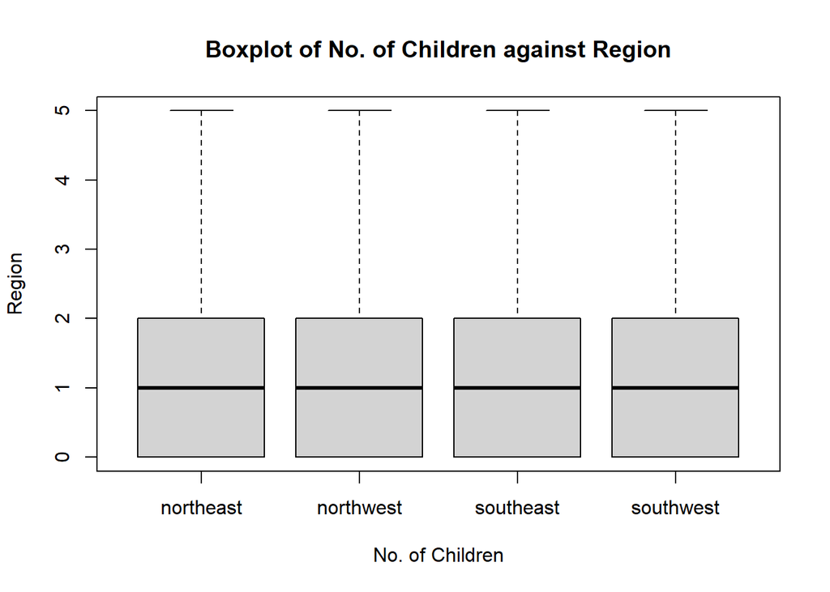

```r
bchild.region <- boxplot(df$children~df$region,
               xlab = "No. of Children",
               ylab = "Region",
               main = "Boxplot of No. of Children against Region")
```

no association

- smoker against region

```r
smoker_region <- df %>%
  count(smoker, region)

smoker_region.spread <- smoker_region %>%
  spread(key = region, value = n, fill = 0)

smoker_region.spread[is.na(smoker_region.spread)] <- 0

kable(smoker_region.spread, caption = "Contingency table for Smoking Status and Region")
```

Contingency table for Smoking Status and Region

| smoker | northeast | northwest | southeast | southwest |
| --- | --- | --- | --- | --- |
| no | 257 | 267 | 273 | 267 |
| yes | 67 | 58 | 91 | 58 |

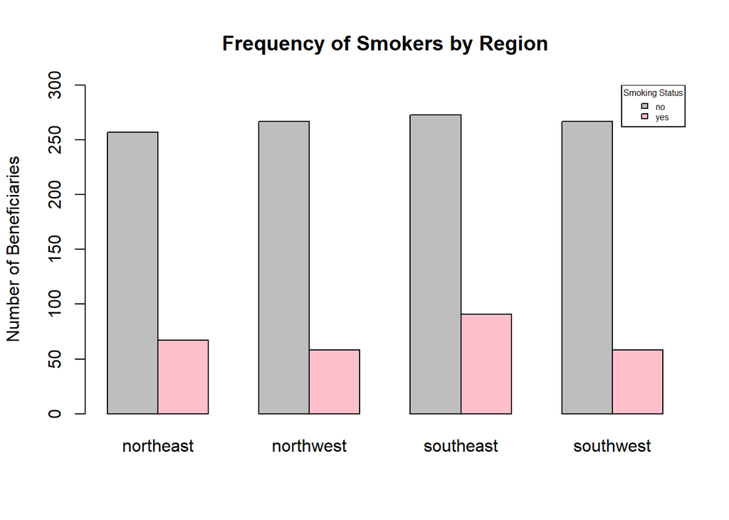

```r
smoker_region.barmatrix <- as.matrix(smoker_region.spread[,c(2:5)])

bar_Col3 <- c("gray","pink")

barplot(smoker_region.barmatrix,
        names.arg = c("northeast", "northwest", "southeast", "southwest"),
        col = bar_Col3,
        beside = TRUE,
        ylim = c(0,300),
        ylab = "Number of Beneficiaries",
        main = "Frequency of Smokers by Region")

legend("topright",
       cex = 0.5,
       fill = bar_Col3,
       legend = smoker_region.spread$smoker,
       title = "Smoking Status")
```

no association

## Prediction

```r
set.seed(123)
train_rows <- sample(nrow(df), 0.8 * nrow(df))
df_train <- df[train_rows, ]
df_test <- df[-train_rows, ]
```

Build regression models to predict insurance charges using features like age, BMI, smoking habits and region.

1. Baseline Model

Response variable vs the most strongly correlated explanatory variables - smoker and age

Let c, s, a denote charges.t, smoker, age.t respectively. For smoker, the reference category is “yes”.

```r
# Convert the 'smoker' variable to a factor. The category "yes" is set as the reference group.
df_train$smoker <- factor(df_train$smoker, levels=c("yes", "no"))
df_train$smoker <- relevel(df_train$smoker, ref="yes")
contrasts(df_train$smoker)
```

```
##     no
## yes  0
## no   1
```

```r
mod.base <- lm(charges.t ~ smoker + age.t, data = df_train)
summary(mod.base)
```

```
##
## Call:
## lm(formula = charges.t ~ smoker + age.t, data = df_train)
##
## Residuals:
##       Min        1Q    Median        3Q       Max
## -0.026867 -0.007323 -0.001377  0.002589  0.068903
##
## Coefficients:
##              Estimate Std. Error t value Pr(>|t|)
## (Intercept)  1.155283   0.004283  269.77   <2e-16 ***
## smokerno    -0.048976   0.001090  -44.94   <2e-16 ***
## age.t        0.089331   0.002681   33.31   <2e-16 ***
## ---
## Signif. codes:  0 '***' 0.001 '**' 0.01 '*' 0.05 '.' 0.1 ' ' 1
##
## Residual standard error: 0.01462 on 1067 degrees of freedom
## Multiple R-squared:  0.7406, Adjusted R-squared:  0.7401
## F-statistic:  1523 on 2 and 1067 DF,  p-value: < 2.2e-16
```

The multiple R-squared statistic (0.7406) indicates that 74.06% of the variation in the dependent variable (charges.t) is explained by the independent variables (smoker and age.t). This suggests that other factors not included in the model might also influence medical insurance charges.

3. Building Improved Models

To improve upon our baseline model (`charges.t ~ smoker + age.t`), we use **forward stepwise selection**. By using this method, we can determine whether adding variables like BMI, number of children, sex, region, or the potential interaction terms identified in the previous section meaningfully improves our baseline model.

```r
# Convert the 'sex' variable to a factor. The category "female" is set as the reference group.
df_train$sex <- factor(df_train$sex, levels=c("female", "male"))
df_train$sex <- relevel(df_train$sex, ref="female")
contrasts(df_train$sex)
```

```
##        male
## female    0
## male      1
```

```r
# Convert the 'region' variable to a factor. The category "northeast" is set as the reference group.
df_train$region <- factor(df_train$region, levels=c("northeast", "northwest", "southeast", "southwest"))
df_train$region <- relevel(df_train$region, ref="northeast")
contrasts(df_train$region)
```

```
##           northwest southeast southwest
## northeast         0         0         0
## northwest         1         0         0
## southeast         0         1         0
## southwest         0         0         1
```

```r
step(mod.base, scope = ~ age.t + smoker + sex + bmi + children + region + bmi*region + age.t*smoker, direction = "forward", trace = 1)
```

```
## Start:  AIC=-9039.76
## charges.t ~ smoker + age.t
##
##                Df Sum of Sq     RSS     AIC
## + age.t:smoker  1  0.035454 0.19251 -9218.6
## + children      1  0.009097 0.21887 -9081.3
## + bmi           1  0.006291 0.22167 -9067.7
## + sex           1  0.000774 0.22719 -9041.4
## + region        3  0.001499 0.22646 -9040.8
## <none>                      0.22796 -9039.8
##
## Step:  AIC=-9218.63
## charges.t ~ smoker + age.t + smoker:age.t
##
##            Df Sum of Sq     RSS     AIC
## + children  1 0.0098341 0.18268 -9272.7
## + bmi       1 0.0049318 0.18758 -9244.4
## + region    3 0.0016470 0.19086 -9221.8
## + sex       1 0.0006233 0.19189 -9220.1
## <none>                  0.19251 -9218.6
##
## Step:  AIC=-9272.74
## charges.t ~ smoker + age.t + children + smoker:age.t
##
##          Df Sum of Sq     RSS     AIC
## + bmi     1 0.0050376 0.17764 -9300.7
## + region  3 0.0017668 0.18091 -9277.1
## + sex     1 0.0007559 0.18192 -9275.2
## <none>                0.18268 -9272.7
##
## Step:  AIC=-9300.66
## charges.t ~ smoker + age.t + children + bmi + smoker:age.t
##
##          Df Sum of Sq     RSS     AIC
## + region  3 0.0029026 0.17474 -9312.3
## + sex     1 0.0011040 0.17653 -9305.3
## <none>                0.17764 -9300.7
##
## Step:  AIC=-9312.29
## charges.t ~ smoker + age.t + children + bmi + region + smoker:age.t
##
##              Df  Sum of Sq     RSS     AIC
## + sex         1 0.00119566 0.17354 -9317.6
## <none>                     0.17474 -9312.3
## + bmi:region  3 0.00078175 0.17395 -9311.1
##
## Step:  AIC=-9317.63
## charges.t ~ smoker + age.t + children + bmi + region + sex +
##     smoker:age.t
##
##              Df Sum of Sq     RSS     AIC
## <none>                    0.17354 -9317.6
## + bmi:region  3 0.0007127 0.17283 -9316.0
```

```
##
## Call:
## lm(formula = charges.t ~ smoker + age.t + children + bmi + region +
##     sex + smoker:age.t, data = df_train)
##
## Coefficients:
##     (Intercept)         smokerno            age.t         children
##       1.2503161       -0.1790058        0.0203757        0.0025735
##             bmi  regionnorthwest  regionsoutheast  regionsouthwest
##       0.0004307       -0.0021368       -0.0038532       -0.0044115
##         sexmale   smokerno:age.t
##      -0.0021305        0.0833601
```

```r
mod <- lm(formula = charges.t ~ smoker + age.t + children + bmi + region + sex + smoker:age.t, data = df_train)

summary(mod)
```

```
##
## Call:
## lm(formula = charges.t ~ smoker + age.t + children + bmi + region +
##     sex + smoker:age.t, data = df_train)
##
## Residuals:
##       Min        1Q    Median        3Q       Max
## -0.025419 -0.006077 -0.002843  0.001624  0.073852
##
## Coefficients:
##                   Estimate Std. Error t value Pr(>|t|)
## (Intercept)      1.2503161  0.0082755 151.087  < 2e-16 ***
## smokerno        -0.1790058  0.0090398 -19.802  < 2e-16 ***
## age.t            0.0203757  0.0051167   3.982 7.29e-05 ***
## children         0.0025735  0.0003265   7.882 7.99e-15 ***
## bmi              0.0004307  0.0000680   6.335 3.51e-10 ***
## regionnorthwest -0.0021368  0.0011236  -1.902 0.057475 .
## regionsoutheast -0.0038532  0.0011296  -3.411 0.000671 ***
## regionsouthwest -0.0044114  0.0011286  -3.909 9.87e-05 ***
## sexmale         -0.0021305  0.0007884  -2.702 0.006993 **
## smokerno:age.t   0.0833601  0.0057706  14.446  < 2e-16 ***
## ---
## Signif. codes:  0 '***' 0.001 '**' 0.01 '*' 0.05 '.' 0.1 ' ' 1
##
## Residual standard error: 0.0128 on 1060 degrees of freedom
## Multiple R-squared:  0.8025, Adjusted R-squared:  0.8009
## F-statistic: 478.7 on 9 and 1060 DF,  p-value: < 2.2e-16
```

```r
vif(mod, type = "predictor")
```

```
## GVIFs computed for predictors
```

```
##              GVIF Df GVIF^(1/(2*Df)) Interacts With
## smoker   1.036683  3        1.006022          age.t
## age.t    1.036683  3        1.006022         smoker
## children 1.009832  1        1.004904           --
## bmi      1.115715  1        1.056274           --
## region   1.106000  3        1.016933           --
## sex      1.014108  1        1.007029           --
##                              Other Predictors
## smoker             children, bmi, region, sex
## age.t              children, bmi, region, sex
## children      smoker, age.t, bmi, region, sex
## bmi      smoker, age.t, children, region, sex
## region      smoker, age.t, children, bmi, sex
## sex      smoker, age.t, children, bmi, region
```

```r
df_test$pred_charges.t <- predict(mod, newdata = df_test)

test_rmse <- sqrt(mean((df_test$charges.t - df_test$pred_charges.t)^2))

test_mae <- mean(abs(df_test$charges.t - df_test$pred_charges.t))

test_r2 <- 1 - sum((df_test$charges.t - df_test$pred_charges.t)^2) / sum((df_test$charges.t - mean(df_test$charges.t))^2)

test_rmse
```

```
## [1] 0.01242761
```

```r
test_mae
```

```
## [1] 0.007776367
```

```r
test_r2
```

```
## [1] 0.8194483
```

The coefficient of determination R-squared (0.8194) indicates that 81.94% of the variation in the dependent variable (charges.t) is explained by the predictors included in the model, namely smoker status, age, number of children, BMI, sex, and region. This indicates that the selected predictors capture the majority of the variation in medical insurance charges, highlighting their strong influence on costs.

## Feature Analysis

n-Fold Cross-Validation for Linear Regression model

```r
set.seed(123)

# Define cross-validation (10-fold CV)
train_control <- trainControl(method = "cv", number = 10)

# Train the model
cv_model <- train(
  charges.t ~ smoker + age.t + children + bmi + region + sex + smoker:age.t,
  data = df,
  method = "lm",
  trControl = train_control
)

# Print summary of CV results
print(cv_model)
```

```
## Linear Regression
##
## 1338 samples
##    6 predictor
##
## No pre-processing
## Resampling: Cross-Validated (10 fold)
## Summary of sample sizes: 1205, 1203, 1204, 1205, 1206, 1204, ...
## Resampling results:
##
##   RMSE        Rsquared  MAE
##   0.01259215  0.808048  0.007900326
##
## Tuning parameter 'intercept' was held constant at a value of TRUE
```

```r
# Extract model performance metrics
cv_results <- cv_model$results
cv_results
```

```
##   intercept       RMSE Rsquared         MAE      RMSESD RsquaredSD       MAESD
## 1      TRUE 0.01259215 0.808048 0.007900326 0.002168924 0.06444163 0.001016233
```

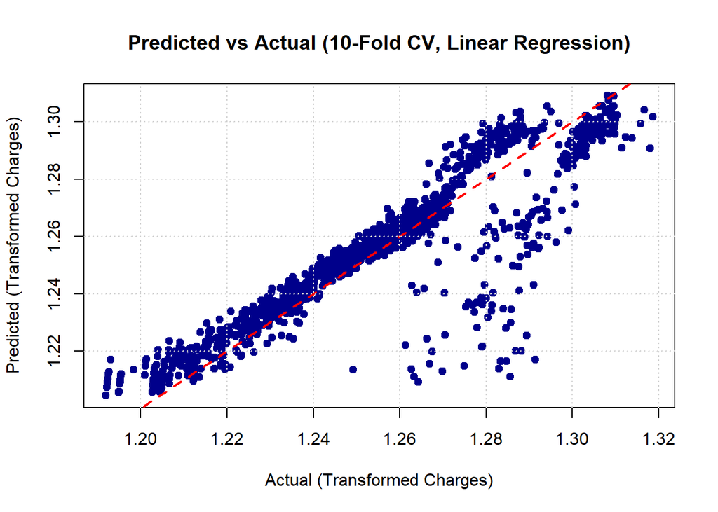

```r
# predicted vs actual plot (base R version)
pred <- predict(cv_model, newdata = df)
plot(df$charges.t, pred,
     main = "Predicted vs Actual (10-Fold CV, Linear Regression)",
     xlab = "Actual (Transformed Charges)",
     ylab = "Predicted (Transformed Charges)",
     pch = 19, col = "darkblue")
abline(0, 1, col = "red", lwd = 2, lty = 2)
grid()
```

## Decision Tree

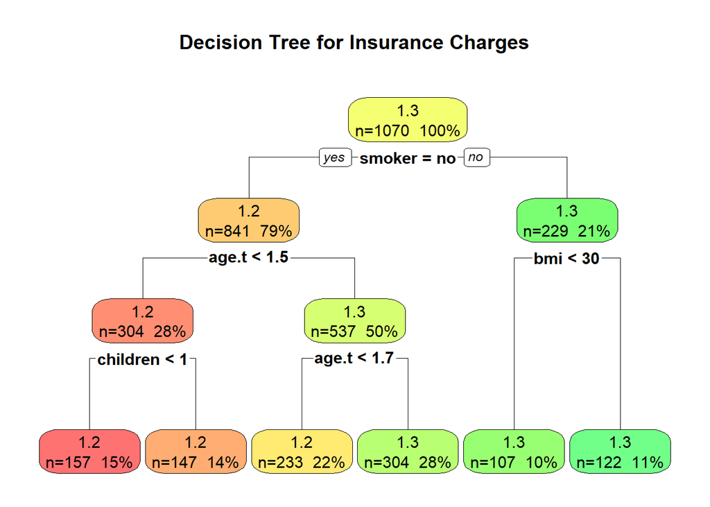

```r
tree_model <- rpart(charges.t ~ age.t + bmi + smoker + sex + children + region,data = df_train,
                    method = "anova",      # for continuous outcome
                    control = rpart.control(cp = 0.01, minsplit = 20))

## 2. Visualize the decision tree
rpart.plot(tree_model,
           main = "Decision Tree for Insurance Charges",
           type = 2, extra = 101, fallen.leaves = TRUE,
           box.palette = "RdYlGn")
```

```r
## 3. Evaluate model on test set
# Predict on test data
df_test$pred_tree <- predict(tree_model, newdata = df_test)

# Compute performance metrics
tree_rmse <- sqrt(mean((df_test$pred_tree - df_test$charges.t)^2))
tree_mae  <- mean(abs(df_test$pred_tree - df_test$charges.t))
tree_r2   <- cor(df_test$pred_tree, df_test$charges.t)^2

cat("\nDecision Tree Performance Metrics:\n")
```

```
##
## Decision Tree Performance Metrics:
```

```r
cat("RMSE:", round(tree_rmse, 4), "\n")
```

```
## RMSE: 0.013
```

```r
cat("MAE:", round(tree_mae, 4), "\n")
```

```
## MAE: 0.0085
```

```r
cat("R-squared:", round(tree_r2, 4), "\n")
```

```
## R-squared: 0.8054
```

```r
## 4. Compare to linear model
comparison <- data.frame(
  Model = c("Linear Regression", "Decision Tree"),
  RMSE = c(test_rmse, tree_rmse),
  MAE = c(test_mae, tree_mae),
  R2 = c(test_r2, tree_r2)
)

print(comparison)
```

```
##               Model       RMSE         MAE        R2
## 1 Linear Regression 0.01242761 0.007776367 0.8194483
## 2     Decision Tree 0.01298851 0.008489725 0.8053991
```

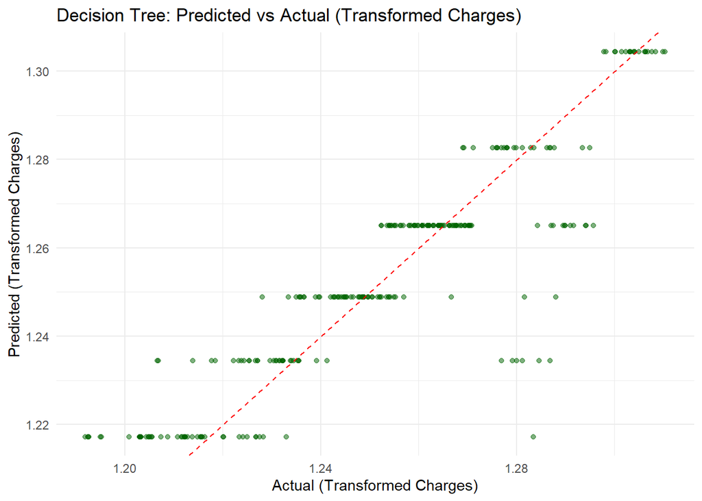

```r
## 5. Visualize predicted vs actual
ggplot(df_test, aes(x = charges.t, y = pred_tree)) +
  geom_point(color = "darkgreen", alpha = 0.5) +
  geom_abline(intercept = 0, slope = 1, color = "red", linetype = "dashed") +
  labs(
    title = "Decision Tree: Predicted vs Actual (Transformed Charges)",
    x = "Actual (Transformed Charges)",
    y = "Predicted (Transformed Charges)"
  ) +
 theme_minimal()
```

```r
# ==========================
##### n-FOLD CROSS-VALIDATION (Decision Tree)

library(caret)
library(rpart)
library(rpart.plot)

# Set random seed for reproducibility
set.seed(123)

# Define number of folds
train_control <- trainControl(method = "cv", number = 10)

# Train the decision tree with cross-validation
tree_cv <- train(
  charges.t ~ age.t + bmi + smoker + sex + children + region,
  data = df,
  method = "rpart",
  trControl = train_control,
  tuneLength = 10,
  metric = "RMSE"
)
# Print CV results
print(tree_cv)
```

```
## CART
##
## 1338 samples
##    6 predictor
##
## No pre-processing
## Resampling: Cross-Validated (10 fold)
## Summary of sample sizes: 1205, 1203, 1204, 1205, 1206, 1204, ...
## Resampling results across tuning parameters:
##
##   cp           RMSE        Rsquared   MAE
##   0.003523915  0.01217103  0.8195375  0.007324960
##   0.004413050  0.01231205  0.8149381  0.007511857
##   0.004703493  0.01236591  0.8130189  0.007665994
##   0.004858431  0.01236591  0.8130189  0.007665994
##   0.011732702  0.01292956  0.7961171  0.008048376
##   0.030081701  0.01402952  0.7626437  0.009567770
##   0.031333740  0.01462517  0.7435428  0.010372769
##   0.041237281  0.01554720  0.7090281  0.011602073
##   0.247963710  0.01902914  0.5606281  0.014943661
##   0.450732398  0.02547710  0.4163425  0.020649330
##
## RMSE was used to select the optimal model using the smallest value.
## The final value used for the model was cp = 0.003523915.
```

```r
cat("\nBest Complexity Parameter (cp):", tree_cv$bestTune$cp, "\n")
```

```
##
## Best Complexity Parameter (cp): 0.003523915
```

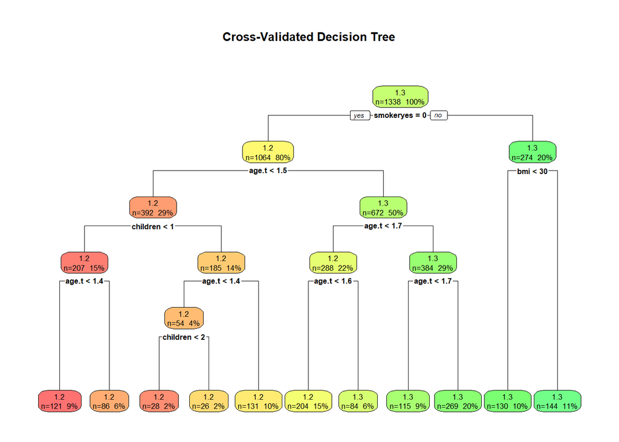

```r
# Visualize the best tree
rpart.plot(tree_cv$finalModel,
           main = "Cross-Validated Decision Tree",
           type = 2, extra = 101, fallen.leaves = TRUE,
           box.palette = "RdYlGn")
```

```r
# Evaluate cross-validated performance
cat("\nCross-Validated RMSE:", round(tree_cv$results$RMSE[which.min(tree_cv$results$RMSE)], 4), "\n")
```

```
##
## Cross-Validated RMSE: 0.0122
```

```r
cat("Cross-Validated R²:", round(tree_cv$results$Rsquared[which.min(tree_cv$results$RMSE)], 4), "\n")
```

```
## Cross-Validated R²: 0.8195
```

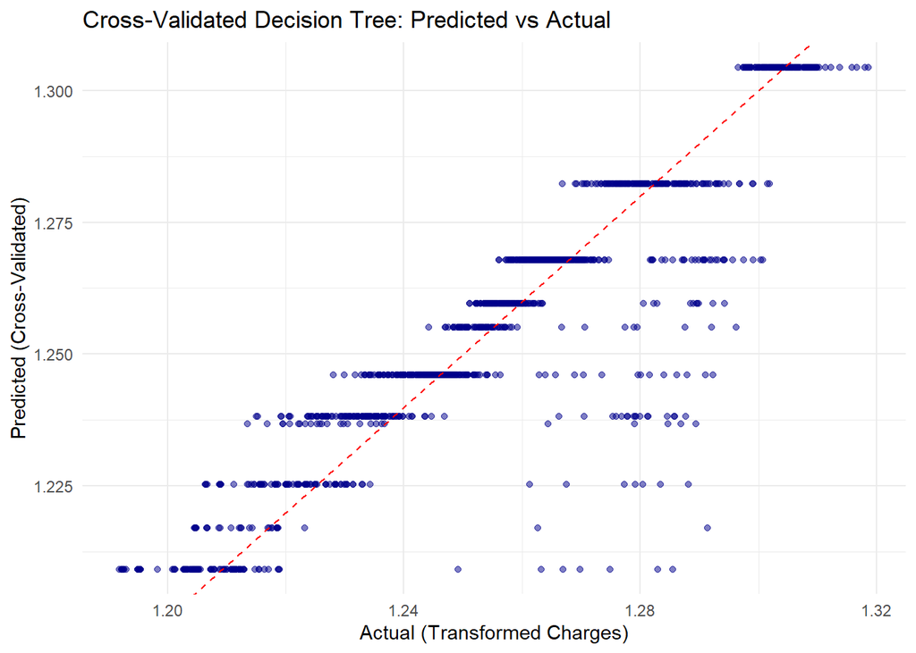

```r
# Eextract predictions for further evaluation
df$cv_pred_tree <- predict(tree_cv, newdata = df)

# Plot predicted vs actual (CV)
library(ggplot2)
ggplot(df, aes(x = charges.t, y = cv_pred_tree)) +
  geom_point(color = "darkblue", alpha = 0.5) +
  geom_abline(intercept = 0, slope = 1, color = "red", linetype = "dashed") +
  labs(
    title = "Cross-Validated Decision Tree: Predicted vs Actual",
    x = "Actual (Transformed Charges)",
    y = "Predicted (Cross-Validated)"
  ) + theme_minimal()
```